# Time Series Forecasts with R

A. Thali

2016-01-23

*Disclaimer: intended as a personal reference and certainly contrains errors of all sorts.*

# Introduction

The subtitle of this vignette should really be: *what little I know about Holt-Winters*.

Here are some references that are smarter about time series analysis than me:

- [Introductory Time Series with R](http://www.springer.com/us/book/9780387886978) by Cowpertwait and Metcalfe
- [Little Book of R for Time Series](https://a-little-book-of-r-for-time-series.readthedocs.org/en/latest/#) by Coghlan
- [Forecasting: Principles and Practice](https://www.otexts.org/book/fpp) by Hyndman and Athanasopoulos

Use those, not this.

## In a nutshell

When trying to use historical time series data to estimate future values, often neither of these two extremes are useful:

- Whatever happened last
  - $\hat{y}_{T+1}=y_{T}$
  - none of the previous data used
- Average over entire series
  - $\hat{y}_{T+1}=\frac{1}{T}\sum_{t=1}^{T}y_{t}$
  - all the previous data are given equal weight

In reality, we want a technique to model the future using past data that takes better advantage of obvious things like trends and seasonal patterns, and that can even make appropriate adjustments for changes in trends and seasonal patterns.

## Assumptions

- sufficient relevant data are available
- it is reasonable to expect past patterns will extend into the future

## Some time series methods

- moving averages
- exponential smoothing techinques
  - Holt-Winters is basically the only technique I have used much
  - `ets()` appears to more robust alternative, but I just learned about it
- ARIMA
  - another robust technique I have not really used

# Load libraries

```r
library(lubridate)  #  wrangling date, time
library(forecast)  #  arima, holt-winters forecasts
library(ggplot2)  #  plotting
library(ggfortify)  #  helps with ggplot-ifying ts charts
library(dygraphs)  #  interactive js visualization of timeseries
library(dplyr)  #  wrangling
library(stringr)  #  wrangling text
library(purrr)  #  new and handy for vector manipulation
library(readr)  #  handy for getting data, not stictly nec.
```

# Time series fundamentals

## Characteristics

- trend: up, down, or flat
- seasonality: a pattern that recurs in fixed period (typically < 1 year)
- cyclic: a pattern that recurs but does not have a fixed period and may be > 1 year

Here is an example of times series data using the Scripps monthly CO<sub>2</sub> atmospheric concentration data (included in R):

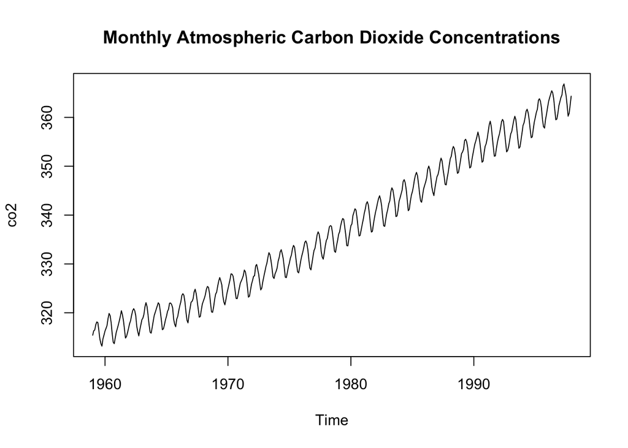

```r
#  note plot.ts, explanation below
plot.ts(co2, main = "Monthly Atmospheric Carbon Dioxide Concentrations")
```

There appears to be:

- a trend
- a seasonal pattern
- the amplitude appears to be constant

Note: `co2` is not a typical data frame, it is an univariate time series:

```r
str(co2)
```

```
##  Time-Series [1:468] from 1959 to 1998: 315 316 316 318 318 ...
```

Many of the packages you might use for time series forecasting are going to make use of `ts` data.

For example, when you visualize `ts` data you end up using base R `plot()`; `ggplot2` does not work because it expects data frames. However, if you want to give your time series plot a `ggplot2` look-and-feel you can load [`ggfortify`](https://cran.rstudio.com/web/packages/ggfortify/vignettes/basics.html) (as I did above), and then use the `autoplot` function.

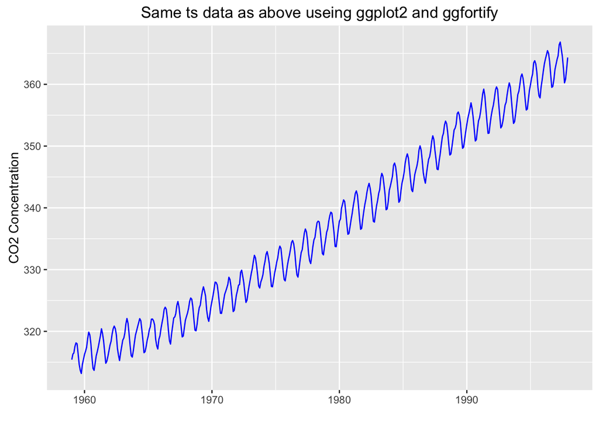

```r
autoplot(co2, ts.colour = "blue") +
    labs(title = "Same ts data as above useing ggplot2 and ggfortify",
         y = "CO2 Concentration")
```

Another way to visualize time series data is: [dygraphs](https://rstudio.github.io/dygraphs/).

```r
library(dygraphs)

dygraph(co2, main = "Interactive version of co2 ts data using dygraphs") %>%
     dyRangeSelector(height = 20)
```

[interactive chart not shown]

Note in the chart above:

- slider control
- hover detail
- parsimonious code
- how little I had to do to make a smart looking chart

## Time series decomposition

$y_{t} = S_{t} + T_{t} + E_{t}$

- $S$ = seasonality
- $T$ = trend
- $E$ = error

The above model is *additive*, meaning the amplitude of the seasonality, error, and trends are constant through levels of the series. In contrast, a *multiplicative* model is used when the amplitude of the seasonal effect or error increases proportionally with the level in the time series.

The `co2` times series appears to have additivie characteristics.

The `stl` function breaks up a times series into the component parts based on Seasonal Decomposition of Time Series by Loess.

```r
stl_co2 <- stl(co2, s.window = "periodic")
```

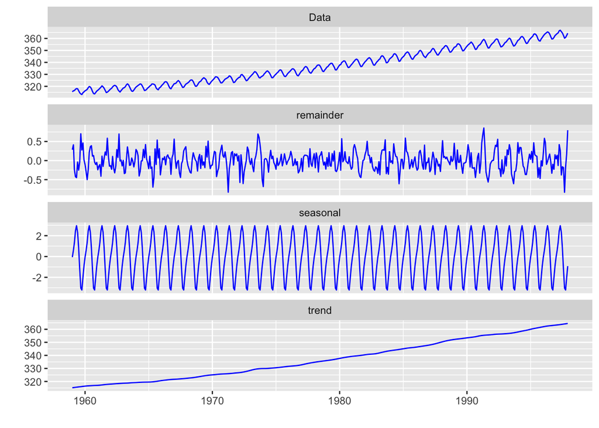

You can see it is literally additive:

```r
co2[196]  #  haphazardly selecting a value from the series
```

```
## [1] 333.14
```

```r
stl_co2$time.series[196,]  #  it's decomposition
```

```
##    seasonal       trend   remainder
##   2.4690471 330.7586583  -0.0877054
```

```r
sum(stl_co2$time.series[196,])  #  sum the parts back to a whole
```

```
## [1] 333.14
```

Q: Why such regular seasonality in CO<sub>2</sub> concentrations?

A: Uneven distribution of land between Northern and Southern hemispheres means that when winter in the North, the South is pulling more CO<sub>2</sub> out of the atmosphere (it’s summer there and photosynthesis is happening). When summer in the North, the South pulls less CO<sub>2</sub> because it’s winter.

Maybe you want to remove seasonality. Decomposition makes this easy.

Using this times series decomposition allows us to generate a *seasonally adjusted* version of the same data by simply taking $y_{t} - S_{t}$. If the times series is multiplicative (not additive), we would do this by: $\frac{y_{t}}{S_{t}}$.

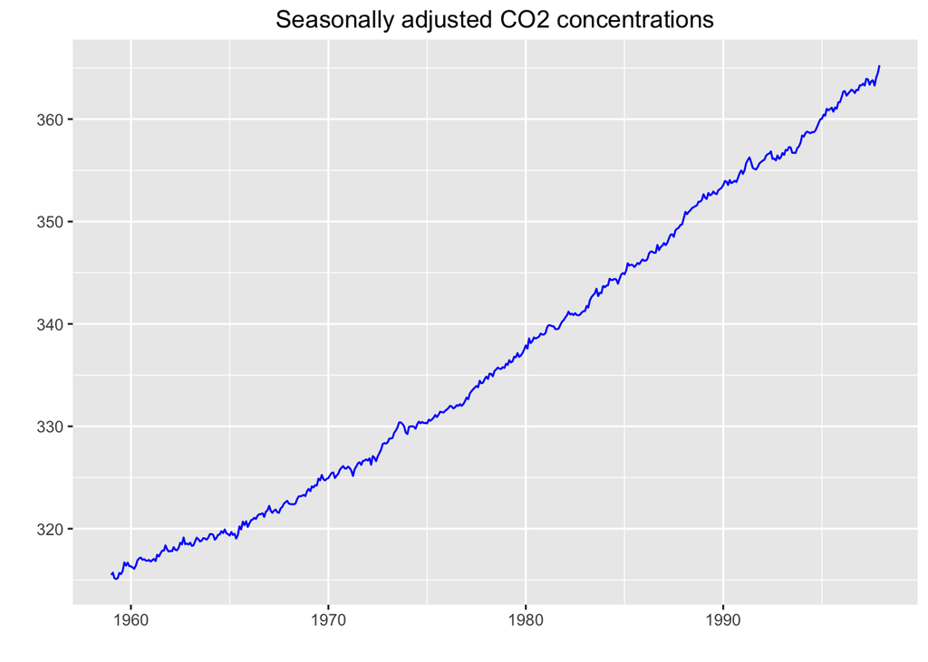

```r
##  by subtracting the seasonality, can plot the adjusted numbers
co2_adj <- co2 - stl_co2$time.series[,1]
```

# Exponential smoothing

## Moving averages

At the foundation of many time series techniques is the notion of a moving average based on the trend cycle: more recent data may be more relevant than really old data. Calculating moving average in `forecast` can be accomplished with `ma()`.

## Simple exponential smoothing

A potential improvement over a simple moving average, naive forecast, or the aggregate average is the notion of *exponential smoothing*.

The idea is to exponentially lower weights for data from further in the past ($\alpha$):
$$\hat{y}_{T+1|T} = \alpha y_{T}+\alpha (1-\alpha)y_{T−1}+\alpha (1−\alpha)^2y_{T−2}+ ...$$

If $\alpha$ = 1, then all the previous data points will zero out.

### Holt Winters

Holt-Winters is a more refined approach to simple exponential smoothing.

There are two more smoother parameters to HW in addition to $\alpha$:

- $\alpha$ overall weight
- $\beta$ trend
- $\gamma$ seasonality

They all range from 0-1:

- If approaching 1, then exponential weighting is shifted toward recent data (not much smoothing)
- If approaching 0, then older data are also given weight and contribute to forecasts.

Setting $\gamma$ and $\beta$ to `FALSE` essentially give a simple exponential smoothing estimate: i.e. no seasonality or trending.

```r
co2_ses <- HoltWinters(co2, beta = FALSE, gamma = FALSE)
co2_ses
```

```
## Holt-Winters exponential smoothing without trend and without seasonal component.
##
## Call:
## HoltWinters(x = co2, beta = FALSE, gamma = FALSE)
##
## Smoothing parameters:
##  alpha: 0.9999339
##  beta : FALSE
##  gamma: FALSE
##
## Coefficients:
##       [,1]
## a 364.3399
```

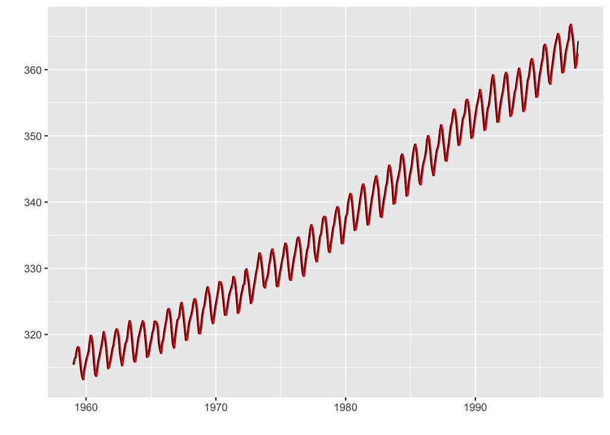

Same function, but with trending and seasonality.

```r
co2_hw <- HoltWinters(co2)  #  note beta, gamma parameters not FALSE
```

- $\alpha$ = 0.5126484
- $\beta$ = 0.0094977
- $\gamma$ = 0.4728868

The $\alpha$ and $\gamma$ are close to .5, suggesting the series level and seasonality are estimated using both recent and older data. The $\beta$ nearing zero suggests the trend (slope) is constant through the series.

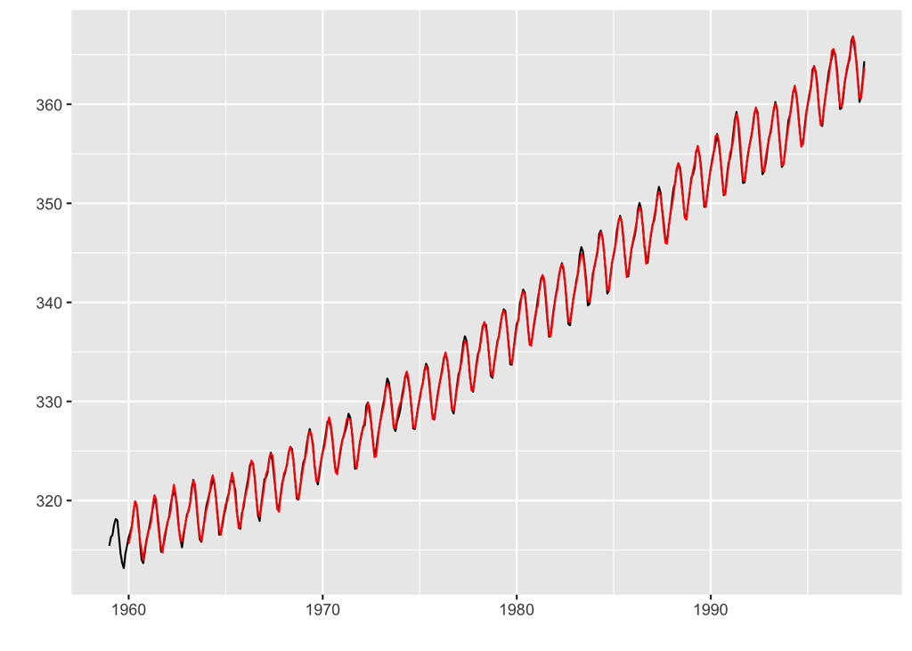

That plot above looks like a pretty good match: the red line is the forecast for the in-sample data. We can check on the match explicitly using the sum of squared error:

```r
co2_hw$SSE
```

```
## [1] 43.12986
```

The `forecast` package makes it easy to project a Holt-Winters model forward.

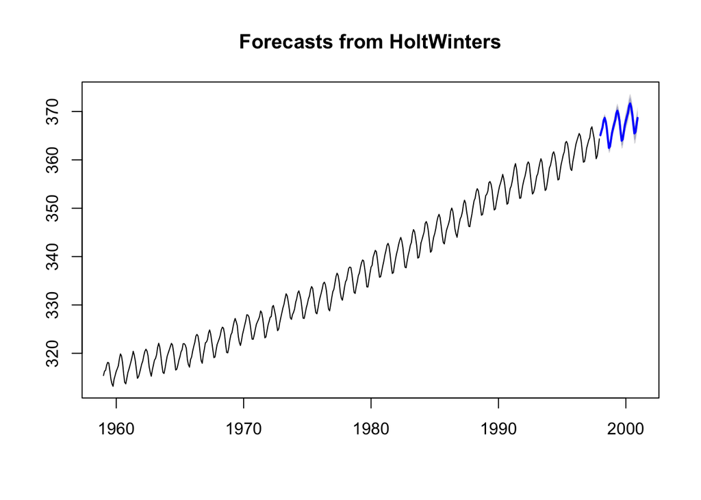

```r
co2_hw_fc <- forecast.HoltWinters(co2_hw, h = 36)
plot.forecast(co2_hw_fc)
```

The function`forecast.HoltWinters()` provides confidence intervals by default.

```
##          Point Forecast    Lo 80    Hi 80    Lo 95    Hi 95
## Jan 1998       365.1079 364.7139 365.5019 364.5053 365.7105
## Feb 1998       365.9664 365.5228 366.4100 365.2879 366.6449
## Mar 1998       366.7343 366.2453 367.2234 365.9864 367.4823
```

### ETS

ETS is an alternative to Holt Winters for exponential smoothing found in the `forecast` package. I really only learned about it as I prepared this vignette, so don’t have much experience with it. However, based on what I learned, I may be using it more and more.

- `HoltWinters()` tries to optimize MSE and uses heurestics for intial values
- `ets()` optimizes the likelihood function for smoother parameters and estimated initial states.
  - `ets()` estimates a smoothing parameter for *damping* ($\phi$).
  - Damping mitigates the potential to over-forecast by flattening trends further in the future.
- According to [Hyndman](http://robjhyndman.com/hyndsight/estimation2/), `ets()` is the more robust of the two.

The syntax is very similar to Holt-Winters.

```r
co2_ets <- ets(co2)
co2_ets
```

```
## ETS(M,Ad,M)
##
## Call:
##  ets(y = co2)
##
##   Smoothing parameters:
##     alpha = 0.6801
##     beta  = 0.0447
##     gamma = 1e-04
##     phi   = 0.9781
##
##   Initial states:
##     l = 315.4865
##     b = 0.0944
##     s=0.9972 0.9939 0.9904 0.9909 0.9963 1.0024
##            1.0069 1.0088 1.0074 1.0041 1.0019 0.9999
##
##   sigma:  8e-04
##
##      AIC     AICc      BIC
## 1718.454 1719.814 1788.978
```

```r
forecast.ets(co2_ets, h = 3)
```

```
##          Point Forecast    Lo 80    Hi 80    Lo 95    Hi 95
## Jan 1998       365.2278 364.8392 365.6164 364.6335 365.8221
## Feb 1998       366.0874 365.6064 366.5685 365.3518 366.8231
## Mar 1998       367.0244 366.4565 367.5923 366.1559 367.8929
```

# ARIMA

Auto-Regressive Integrated Moving Averages (ARIMA) models are another widely used technique, which I just have not used or understand well enough to explain in any detail. Essentially, it uses regression to compare the time series to lagged values of the time series.

However, if you are happy to treat them as a black box and let the math faeries do their thing, R makes it easy enough to do that using `auto.arima()`. Beware, math faeries can be mean.

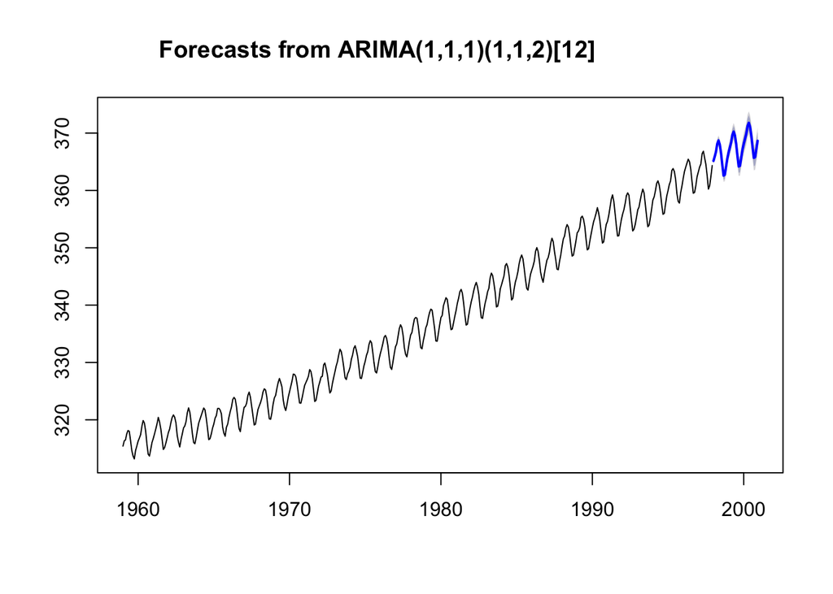

```r
co2_arima <- auto.arima(co2)
co2_arima_fc <- forecast.Arima(co2_arima, h = 36)
plot.forecast(co2_arima_fc)
```